# Final Project

# Directive 3

To assess whether any of the measured baseline variables were marginally associated with differences in disease-free survival, for each baseline variable of interest, we fit a Cox proportional hazards model. Survival curves estimated using the Cox model were also presented, where, for continuous random variables, separate curves were included for the 25th and 75th quantile.

> Are any of the measured baseline variables associated with differences in disease-free survival?
- We think this is referring to marginal (univariable) associations
- Include cox models for all variables (assess proportionality of hazards)
- Include kaplan meier curves for the categorical ones (with confidence intervals)

Optional: for continuous covariates, get survival curves from the cox models - could plot survival curve for specific values Think about potentially adding a fully adjusted model Could create a DAG and outline the causal assumptions that would be needed

`tdfs`: time until relapse, death or end of study (in days) `deltadfs:` disease-free survival indicator 1 = dead or relapsed 0 = alive and disease-free

patient age and sex, donor age and sex, patient and donor cytomegalovirus (CMV) immune status, the wait time from diagnosis to transplantation, disease group, French-American-British (FAB) classification based on standard morphological criteria, and prophylactic use of methotrexate to prevent aGVHD

```r
#---------------------------
# Directive 3
#---------------------------

# column names of all baseline variables of interest
covariates <- c("age", "donorage",
                "male", "donormale",
                "cmv", "donorcmv",
                "waittime", "disgroup", "fab", "mtx")

# readable names of all baseline variables of interest
nice_names <- c("Age",  "Donor Age",
                "Sex", "Donor Sex",
                "CMV", "Donor CMV",
                "Wait Time for Transplant", "Disease Group",
                "FAB Group", "Prophylactic Use\nof Methotrexate")

# read in the dataset and relabel factor variables to have meaningful levels
bmt <- read_csv(here("data/bmt.csv")) %>%
  mutate(across(c(male, cmv, donorcmv, disgroup, donormale, fab, mtx),
                as_factor)) %>%
  mutate(male = ifelse(male==1, "Male", "Female"),
         male = factor(male, levels=c("Female", "Male")),
         donormale = ifelse(donormale==1, "Male", "Female"),
         donormale = factor(donormale, levels=c("Female", "Male")),
         cmv = ifelse(cmv==1, "CMV Positive", "CMV Negative"),
         cmv = factor(cmv,
                      levels=c("CMV Negative", "CMV Positive")),
         donorcmv = ifelse(donorcmv==1, "CMV Positive", "CMV Negative"),
         donorcmv = factor(donorcmv,
                           levels=c("CMV Negative", "CMV Positive")),
         disgroup = case_when(
           disgroup == 1 ~ "Acute Lymphoblastic Leukemia",
           disgroup == 2 ~ "Acute Myelocytic Leukemia (Low Risk)",
           disgroup == 3 ~ "Acute Myelocytic Leukemia (High Risk)"),
         disgroup=factor(disgroup,
                         levels =c("Acute Lymphoblastic Leukemia",
                                   "Acute Myelocytic Leukemia (Low Risk)",
                                    "Acute Myelocytic Leukemia (High Risk)")),
         fab=ifelse(fab==1, "FAB grade 4 or 5 and AML", "Other"),
         fab=factor(fab, levels =c("Other",
                                   "FAB grade 4 or 5 and AML")),
         mtx = ifelse(mtx==1, "Prophylactic Use of Methotrexate",
                       "No Prophylactic Use of Methotrexate"),
         mtx=factor(mtx, levels=c("No Prophylactic Use of Methotrexate",
                                  "Prophylactic Use of Methotrexate")),
         hospital = factor(hospital),
         waittime=waittime/365
         )
```

```r
# get kaplan-meier curve by a continuous variable
# by splitting the continuous variable into two groups
# by whether the value of the variable was above or below
# the median
get_continuous_km <- function(var, nice_name) {

  # calculate median of the continuous variable of interest
  median_var <- bmt[[var]] %>% median(na.rm=TRUE)

  bmt_w_thresh <- bmt %>% mutate(
    !!sym(var) := ifelse(!!sym(var) > median_var,
                          paste0("> ", median_var),
                          paste0("≤ ", median_var)))

  # Fit model with thresholded version of continuous covariate
  fit <- survfit(as.formula(paste0("Surv(tdfs, deltadfs) ~ ", var)),
     data = bmt_w_thresh)

  # kaplan-meier plot
  ggsurvfit(fit)$data %>%
    select(estimate, strata, time, conf.high, conf.low) %>%
    dplyr::arrange(strata, time) |>
    dplyr::group_by(strata) |>
    dplyr::mutate(
    xmin = time,
    xmax = dplyr::lead(time)   # next step’s start
    ) |>
    dplyr::ungroup() |>
    dplyr::filter(!is.na(xmax))  %>%
    mutate(strata=gsub(paste0(var,"="),
                       nice_name,
                       strata)) %>%
    ggplot(aes(x=time, y=estimate,color=strata,
               fill=strata)) +
    geom_step() +
    geom_rect(aes(xmin = xmin, xmax = xmax,
                ymin = conf.low, ymax = conf.high,
                fill=strata),
              alpha = 0.15,
              inherit.aes=FALSE) +
    theme_c() +
    viridis::scale_color_viridis(discrete=TRUE,
                                 option="mako", end=.8, begin=.2) +
    viridis::scale_fill_viridis(discrete=TRUE,
                                 option="mako", end=.8, begin=.2) +
    labs(y="Disease-Free Survival", x= "Time (Days)",
          title=paste0("By ", nice_name),
         fill="", color="") +
    scale_x_continuous(n.breaks=7)
}



# get kaplan meier curve by a discrete variable
get_discrete_km <- function(var, nice_name) {

  # Fit model with discrete covariate
  fit <- survfit(as.formula(paste0("Surv(tdfs, deltadfs) ~ ", var)),
     data = bmt)

  # kaplan-meier plot
  ggsurvfit(fit)$data %>%
    select(estimate, strata, time, conf.high, conf.low) %>%
    dplyr::arrange(strata, time) |>
    dplyr::group_by(strata) |>
    dplyr::mutate(
    xmin = time,
    xmax = dplyr::lead(time)   # next step’s start
  ) |>
    mutate(strata=gsub(paste0(var,"="),
                       "",
                       strata)) %>%
    ggplot(aes(x=time,y=estimate,color=strata)) +
    geom_step() +
    geom_rect(aes(xmin = xmin, xmax = xmax,
                ymin = conf.low, ymax = conf.high,
                fill=strata),
              alpha = 0.15,
              inherit.aes=FALSE) +
    theme_c() +
    viridis::scale_color_viridis(discrete=TRUE,
                                 option="magma", end=.8, begin=.3) +
    viridis::scale_fill_viridis(discrete=TRUE,
                                 option="magma", end=.8, begin=.3) +
    labs(y="Disease-Free Survival", x= "Time (Days)",
         title=paste0("By ", nice_name), color="", fill="") +
    scale_x_continuous(n.breaks=7)

}


get_continuous_survival_curve <- function(var, nice_name) {

  mod <- coxph(as.formula(paste0("Surv(tdfs, deltadfs) ~ ", var)),
     data = bmt)

  newdat <- tibble(
    !!var := quantile(bmt[[var]],probs= c(.25,.75), na.rm=TRUE))


  est_by_group <- pmap_df(newdat, ~{
    ggsurvfit(survfit(mod, newdata =tibble(!!var := .x)))$data %>%
      mutate(strata = .x)}
    )

  est_by_group %>%
    select(estimate, strata, time, conf.high, conf.low) %>%
    dplyr::arrange(strata, time) |>
    dplyr::group_by(strata) |>
    dplyr::mutate(
    xmin = time,
    xmax = dplyr::lead(time)   # next step’s start
  ) |>
    mutate(strata=gsub(paste0(var,"="),
                       "",
                       strata)) %>%
    ggplot(aes(x=time,y=estimate,color=strata)) +
    geom_step() +
    geom_rect(aes(xmin = xmin, xmax = xmax,
                ymin = conf.low, ymax = conf.high,
                fill=strata),
              alpha = 0.15,
              inherit.aes=FALSE) +
    theme_c() +
    viridis::scale_color_viridis(discrete=TRUE,
                                 option="magma", end=.8, begin=.3) +
    viridis::scale_fill_viridis(discrete=TRUE,
                                 option="magma", end=.8, begin=.3) +
    labs(y="Disease-Free Survival", x= "Time (Days)",
         title=paste0("By ", nice_name), color="", fill="") +
    scale_x_continuous(n.breaks=7)

}



# get kaplan meier curve corresponding to given covariate
get_km_curve <- function(var, nice_name) {
  if(is.factor(bmt[[var]])) {
    plot <- get_discrete_km(var, nice_name)
  }
  else {
    plot <- get_continuous_km(var, nice_name)
  }
  return(plot)
}


# iterate over all baseline variables of interest
pltlist <- map2(covariates,nice_names, get_km_curve)
```

[figure not shown]

```r
get_survival_curve <- function(var, nice_name) {

  mod <- coxph(as.formula(paste0("Surv(tdfs, deltadfs) ~ ", var)),
     data = bmt)

  if (is.factor(bmt[[var]])) {
    newdat <- tibble(
    !!var := unique(bmt[[var]])
  )
  }
  else {
    newdat <- tibble(
    !!var := round(quantile(bmt[[var]],probs= c(.25,.75), na.rm=TRUE),2))

  }


  est_by_group <- pmap_df(newdat, ~{
    ggsurvfit(survfit(mod, newdata =tibble(!!var := .x)))$data %>%
      mutate(strata = .x)}
    )

  if(!is.factor(bmt[[var]]))  {
    est_by_group <- est_by_group %>%
      mutate(strata=paste0(nice_name, " = ", strata))
  }

  est_by_group %>%
    select(estimate, strata, time, conf.high, conf.low) %>%
    dplyr::arrange(strata, time) |>
    dplyr::group_by(strata) |>
    dplyr::mutate(
    xmin = time,
    xmax = dplyr::lead(time)   # next step’s start
  ) |>
    mutate(strata=gsub(paste0(var,"="),
                       "",
                       strata)) %>%
    ggplot(aes(x=time,y=estimate,color=strata)) +
    geom_step() +
    geom_rect(aes(xmin = xmin, xmax = xmax,
                ymin = conf.low, ymax = conf.high,
                fill=strata),
              alpha = 0.15,
              inherit.aes=FALSE) +
    theme_c() +
    viridis::scale_color_viridis(discrete=TRUE,
                                 option="magma", end=.8, begin=.3) +
    viridis::scale_fill_viridis(discrete=TRUE,
                                 option="magma", end=.8, begin=.3) +
    labs(y="Disease-Free Survival", x= "Time (Days)",
         title=paste0("By ", nice_name), color="", fill="") +
    scale_x_continuous(n.breaks=7)

}

pltlist <- map2(covariates,nice_names,get_survival_curve)

# package for arranging plots
library(patchwork)

# arrange plots into a grid
(pltlist[[1]] + pltlist[[2]])/ (pltlist[[3]] + pltlist[[4]]) / (pltlist[[5]] + pltlist[[6]]) / (pltlist[[7]] + pltlist[[8]])/(pltlist[[9]] + pltlist[[10]]) + plot_annotation(
  title = "Kaplan-Meier Curves by Baseline Variables of Interest",
  theme=theme_c(plot.title=element_text(face="bold",hjust=.5, size=20)))
```

```r
# save plot
ggsave(here("figures/km_by_baseline.jpeg"))
```

```r
library(gt)
library(gtsummary)

get_model_summary <- function(var, nice_name, model) {

  # model <- coxph(as.formula(paste0("Surv(tdfs, deltadfs) ~ ", var)),
  #    data = bmt)

  if (var == "male" | var == "donorcmv" | var == "donormale" ) {
    model_summary <- tbl_regression(model, exponentiate=TRUE,
                                  conf.level=.9,
                 estimate_fun=label_style_sigfig(digits=3),
                 pvalue_fun = label_style_pvalue(digits = 3),
                 show_single_row=all_of(var),
                 label=setNames(
                   list(nice_name, paste0("tt(", nice_name, ")")),
                   c(var, paste0("tt(",var, ")"))))
  }

  model_summary <- tbl_regression(model, exponentiate=TRUE,
                                  conf.level=.9,
                 estimate_fun=label_style_sigfig(digits=3),
                 pvalue_fun = label_style_pvalue(digits = 3),
                 label=setNames(
                   list(nice_name, paste0("tt(", nice_name, ")")),
                   c(var, paste0("tt(",var, ")"))))
  return(model_summary)

}
```

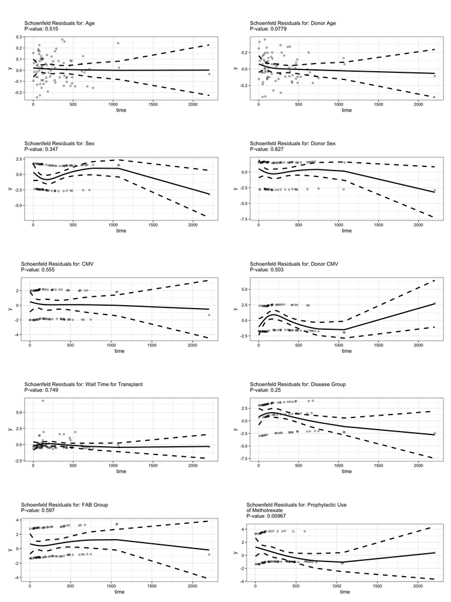

```r
get_model <- function(var) {

  model <- coxph(as.formula(paste0("Surv(tdfs, deltadfs) ~ ", var)),
     data = bmt)

  return(model)

}

model_list <- map(covariates, get_model)
names(model_list) <- covariates


# linear spline basis 1: min(t, c) # basis 2: (t - c)+)
#----------------------------
# plot Schoenfeld residuals
#----------------------------

library(splines)

get_res_plot <- function(var, nice_name, model) {

  res <- as.data.frame(cox.zph(model, transform="km")$y)[[var]]
  pval <- cox.zph(model, transform="km")$table[var,"p"] %>%
    signif(3)

  if(is.null(res)) {return(NULL)}
  time <- cox.zph(model, transform="km")$time
  df <- tibble(var = var,
         time = time,
          y=res)
  # glimpse(df)

  spline_fit <- lm(y ~ ns(time, df = 3), data = df)
  ci <- predict(spline_fit, newdata = df,
                interval = "confidence",
                level = 0.95)
  df_ci <- bind_cols(df, as.data.frame(ci))

  df_ci %>%
    mutate(
      spline = predict(spline_fit)
    ) %>%
      ggplot(aes(x=time)) +
       geom_point(aes(y=y),alpha=.3) +
       geom_line(aes(x=time,y=upr), linetype=2, linewidth=1.05) +
       geom_line(aes(x=time,y=lwr), linetype=2, linewidth=1.05) +
       geom_line(aes(x=time,y=spline),linewidth=1.05) +
    theme_c(plot.title=element_text(face="plain", size=10,hjust=0)) +
    labs(title=paste0(
                      "\nSchoenfeld Residuals for: ", nice_name,
                      "\nP-value: ", pval,
                       "\n"))

}

plotlist <- pmap(list(var=covariates,
          nice_name=nice_names,
          model=model_list),
     get_res_plot)


cowplot::plot_grid(plotlist=plotlist,ncol=2)
```

```r
#-------------------------------------------------------------
# add time-varying covariates based on residual plots above
#-------------------------------------------------------------


# linear interaction with time
model_list[["donorage"]] <- coxph(
  Surv(tdfs, deltadfs) ~ donorage + tt(donorage),
     data = bmt,
      tt=function(x,t,...) x*t )


# piecewise linear interaction with time (to handle U-shapes)
# before the cutpoint, slope is beta_1
# after the cutpoint, slope is beta_2
# continuous at cutpoint
model_list[["mtx"]] <- coxph(
  Surv(tdfs, deltadfs) ~ mtx + tt(mtx),
     data = bmt %>% mutate(mtx = ifelse(
       mtx=="Prophylactic Use of Methotrexate", 1, 0)),
      tt=function(x,t,...) cbind( x * pmin(t, 600), x * pmax(0, t - 600)))
```

```r
model_summary_list <- pmap(list(var=covariates,
                                nice_name=nice_names,
                                model=model_list),
                           get_model_summary)

tbl_stack(model_summary_list,
          group_header=paste0('Model: ', nice_names)) %>%
  as_gt() %>%
  gt::tab_style(
    style = cell_text(weight = "bold"),
    locations = cells_row_groups()
  )
```

| **Characteristic** | **HR**<sup>1</sup> | **90% CI**<sup>1</sup> | **p-value** |
| --- | --- | --- | --- |
| Model: Age |  |  |  |
| Age | 1.01 | 0.992, 1.03 | 0.338 |
| Model: Donor Age |  |  |  |
| Donor Age | 1.03 | 1.00, 1.06 | 0.063 |
| tt(Donor Age) | 1.00 | 1.00, 1.00 | 0.139 |
| Model: Sex |  |  |  |
| Sex |  |  |  |
| Female | — | — |  |
| Male | 0.795 | 0.552, 1.15 | 0.301 |
| Model: Donor Sex |  |  |  |
| Donor Sex |  |  |  |
| Female | — | — |  |
| Male | 0.991 | 0.681, 1.44 | 0.970 |
| Model: CMV |  |  |  |
| CMV |  |  |  |
| CMV Negative | — | — |  |
| CMV Positive | 1.17 | 0.813, 1.68 | 0.482 |
| Model: Donor CMV |  |  |  |
| Donor CMV |  |  |  |
| CMV Negative | — | — |  |
| CMV Positive | 1.05 | 0.726, 1.51 | 0.836 |
| Model: Wait Time for Transplant |  |  |  |
| Wait Time for Transplant | 0.970 | 0.806, 1.17 | 0.791 |
| Model: Disease Group |  |  |  |
| Disease Group |  |  |  |
| Acute Lymphoblastic Leukemia | — | — |  |
| Acute Myelocytic Leukemia (Low Risk) | 0.563 | 0.351, 0.903 | 0.046 |
| Acute Myelocytic Leukemia (High Risk) | 1.47 | 0.945, 2.28 | 0.152 |
| Model: FAB Group |  |  |  |
| FAB Group |  |  |  |
| Other | — | — |  |
| FAB grade 4 or 5 and AML | 1.89 | 1.31, 2.73 | 0.004 |
| Model: Prophylactic Use of Methotrexate |  |  |  |
| Prophylactic Use of Methotrexate | 3.12 | 1.61, 6.05 | 0.005 |
| tt(Prophylactic Use of Methotrexate) |  |  |  |
| tt(mtx)1 | 0.997 | 0.994, 1.00 | 0.083 |
| tt(mtx)2 | 0.965 | 0.867, 1.07 | 0.587 |

<sup>1</sup> HR = Hazard Ratio, CI = Confidence Interval

```r
rm(model_summary_list)
```

```r
# Fit model with continuous covariate
fit <- coxph(Surv(tdfs, deltadfs) ~ donorage, data = bmt)

# Choose representative values (e.g., quartiles)
quantiles <- quantile(bmt$donorage, probs = c(.1, .5, .9))
newdat <- data.frame(donorage = quantiles)

# Generate survival predictions
sf <- survfit(fit, newdata = newdat)

sf$surv %>%
  as_tibble() %>%
  mutate(time = sf$time) %>%
  pivot_longer(-c(time)) %>%
  ggplot(aes(x=time, y=value, color=name)) +
  geom_step()



tibble(time=sf$time,
       surv = sf$surv) %>%
  ggplot(aes(x=time, y=surv)) +
  geom_step()

plot(sf)

ggsurvfit(sf)
```

# Directive 6

While death is a competing event for the development of aGVHD, this is not a problem in our sample because no patient died before developing aGVHD, and hence we do not need to explicitly handle competing events for this analysis.

```r
#------------------
# Directive 6
#------------------

confounders <- c("age", "donorage", "waittime", "fab",
                 "male", "donormale", "cmv", "donorcmv",
                 "disgroup", "hospital")

bmt %>%
  group_by(hospital) %>%
  summarise(
    across(all_of(confounders[-length(confounders)]),
           n_distinct))
```

```
## # A tibble: 4 × 10
##   hospital   age donorage waittime   fab  male donormale   cmv donorcmv disgroup
##   <fct>    <int>    <int>    <int> <int> <int>     <int> <int>    <int>    <int>
## 1 1           32       32       39     2     2         2     2        2        3
## 2 2           13       14       13     2     2         2     2        2        3
## 3 3           18       17       18     2     2         2     2        2        3
## 4 4           16       18       11     2     2         2     2        2        2
```

```r
cor(bmt %>% select(all_of(confounders)) %>%
  select(where(is.numeric)))
```

```
##                 age    donorage    waittime
## age       1.0000000  0.75742264 -0.14436978
## donorage  0.7574226  1.00000000 -0.04763487
## waittime -0.1443698 -0.04763487  1.00000000
```

```r
bmt <- bmt %>%
  mutate(sex_mismatch = paste0(donormale, "->", male),
         sex_mismatch = ifelse(sex_mismatch == "Male->Male",
                               "Match", sex_mismatch),
         sex_mismatch = ifelse(sex_mismatch == "Female->Female",
                               "Match", sex_mismatch),
         sex_mismatch = factor(
           sex_mismatch,
           levels=c("Match", "Male->Female","Female->Male")),
         cmv_mismatch = paste0(donorcmv, "->", cmv),
         cmv_mismatch = factor(
           cmv_mismatch,
           levels=c("CMV Negative->CMV Negative",
                    "CMV Negative->CMV Positive",
                    "CMV Positive->CMV Negative",
                    "CMV Positive->CMV Positive"))
        #  sex_mismatch = ifelse(sex_mismatch == "Female->Male", 1, 0),
        # cmv_mismatch = ifelse(cmv_mismatch ==
        #                         "CMV Negative->CMV Positive",
        #                       1,0)
        )
```

## Perfect Collinearity by Hospital

```r
# perfect collinearity
table(bmt$hospital, bmt$mtx)
```

```
##
##     No Prophylactic Use of Methotrexate Prophylactic Use of Methotrexate
##   1                                  76                                0
##   2                                   0                               17
##   3                                   0                               23
##   4                                  21                                0
```

## No Patient Dies Before aGVHD

```r
bmt %>%
  filter(ts < ta) %>%
  nrow()
```

```
## [1] 0
```

### Including FAB

```r
model <- coxph(Surv(ta, deltaa) ~
                 mtx + age + donorage +
                # waittime +
                 fab + disgroup+
                 sex_mismatch  +
                 cmv_mismatch, data=bmt
               )
```

### Excluding FAB

```r
model <- coxph(Surv(ta, deltaa) ~
                 mtx + age + donorage +
                # waittime + fab +
                 disgroup+
                 sex_mismatch  +
                 cmv_mismatch,
               data=bmt
               )
```

## Proportional Hazards Assumption

```r
cox.zph(model, transform="km")$table %>%
  as.data.frame() %>%
  kbl(caption="Proportional Hazards Test") %>%
  kable_paper()
```

Proportional Hazards Test

|  | chisq | df | p |
| --- | --- | --- | --- |
| mtx | 0.1608288 | 1 | 0.6883946 |
| age | 1.1104426 | 1 | 0.2919858 |
| donorage | 1.2587468 | 1 | 0.2618884 |
| disgroup | 4.6988143 | 2 | 0.0954257 |
| sex_mismatch | 2.9001290 | 2 | 0.2345552 |
| cmv_mismatch | 3.0752872 | 3 | 0.3801624 |
| GLOBAL | 10.7956582 | 10 | 0.3736583 |

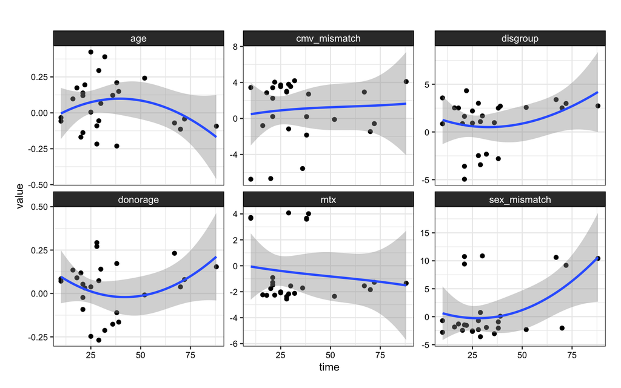

```r
mod_resid <- as.data.frame(cox.zph(model, transform="km")$y) %>%
  as_tibble()

time <- cox.zph(model, transform="km")$time

df <- mod_resid %>%
  bind_cols(time=time)

df %>%
  pivot_longer(-time) %>%
  ggplot(aes(x=time,y=value)) +
  geom_point() +
  geom_smooth(formula=y~x,method="loess",span=5) +
  facet_wrap(~name, scales="free_y") +
  theme_c()
```

```r
mod_resid <- as.data.frame(cox.zph(model, transform="km")$y) %>%
  as_tibble()

time <- cox.zph(model, transform="log")$time

df <- mod_resid %>%
  bind_cols(time=time)

df %>%
  pivot_longer(-time) %>%
  ggplot(aes(x=time,y=value)) +
  geom_point() +
  geom_smooth(formula=y~x,method="loess",span=5) +
  facet_wrap(~name, scales="free_y") +
  theme_c()


df %>%
  pivot_longer(-time) %>%
  ggplot(aes(x=time,y=value)) +
  geom_point() +
  geom_smooth(formula=y~x,method="loess",span=5) +
  facet_wrap(~name, scales="free_y") +
  theme_c()

model <- coxph(Surv(ta, deltaa) ~
                 mtx + age + donorage +
                 tt(waittime) +
                 fab + disgroup+
                 sex_mismatch  +
                 cmv_mismatch, data=bmt,
               tt=function(x,t,...) x*splines::ns(t,df=2))
```

## G-Computation

```r
#------------------------------------------------------------
# g-computation to compute marginalized survival curves
#------------------------------------------------------------
surv_treat <- survfit(model, newdata=bmt %>%
          mutate(mtx="Prophylactic Use of Methotrexate")) %>%
  broom::tidy() %>%
  rowwise() %>%
  mutate(
    mean_surv = mean(c_across(contains("estimate")), na.rm = TRUE)
  ) %>%
  ungroup() %>%
  select(time, mean_surv)

surv_no_treat <- survfit(model, newdata=bmt %>%
          mutate(mtx="No Prophylactic Use of Methotrexate")) %>%
  broom::tidy() %>%
  rowwise() %>%
  mutate(
    mean_surv = mean(c_across(contains("estimate")), na.rm = TRUE)
  ) %>%
  ungroup() %>%
  select(time, mean_surv)

surv_est_dir6 <- surv_treat %>%
  mutate(treatment="Prophylactic Use of Methotrexate") %>%
  bind_rows(surv_no_treat %>%
              mutate(treatment="No Prophylactic Use of Methotrexate"))
```

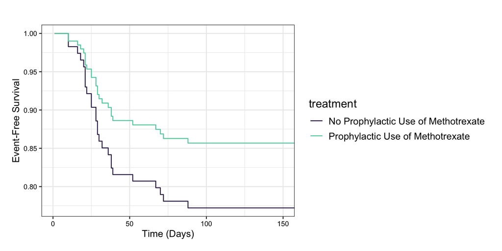

```r
surv_est_dir6 %>%
  ggplot(aes(x=time, y=mean_surv, color=treatment))+
  geom_step() +
  coord_cartesian(xlim=c(0,150)) +
  theme_c(axis.title=element_text(size=11),
          legend.text=element_text(size=11),
          legend.title=element_text(size=13)) +
  viridis::scale_color_viridis(
      discrete=TRUE, option="mako", end=.8, begin=.2) +
  labs(x="Time (Days)", y = "Event-Free Survival")
```

```r
ggsave(here("figures/directive_6.jpeg"))
```

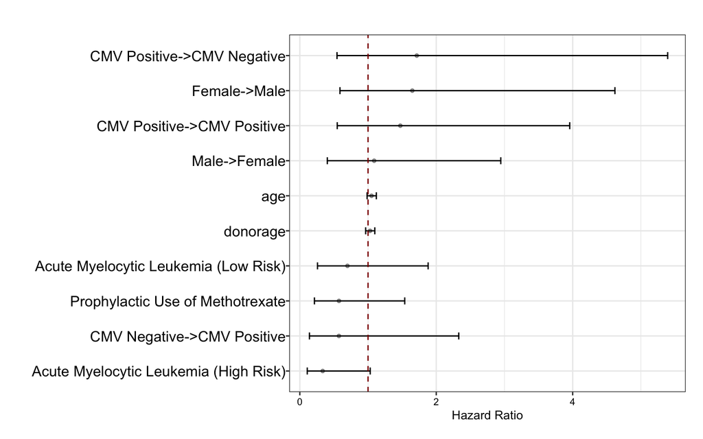

```r
# cox.zph(model)


broom::tidy(model,
            exponentiate=TRUE,
            conf.int=TRUE) %>%
  mutate(term=gsub(
    "sex_mismatch|disgroup|cmv_mismatch|fab|mtx",
    "",term)) %>%
  mutate(term=factor(term),
         term=fct_reorder(term,estimate)) %>%
  ggplot(aes(y=term, xmin=conf.low,xmax=conf.high))+
  geom_point(aes(x=estimate), alpha=.4, size=1.1) +
  geom_errorbar(width=.2) +
  geom_vline(aes(xintercept=1),
             color='darkred',
             linetype=2) +
  theme_c(axis.text.y=element_text(size=12, hjust=1)) +
  labs(y="", x= "Hazard Ratio")
```

```r
gtsummary::tbl_regression(model,conf.level=.9,exponentiate=TRUE)
```

| **Characteristic** | **HR**<sup>1</sup> | **90% CI**<sup>1</sup> | **p-value** |
| --- | --- | --- | --- |
| mtx |  |  |  |
| No Prophylactic Use of Methotrexate | — | — |  |
| Prophylactic Use of Methotrexate | 0.57 | 0.25, 1.31 | 0.3 |
| age | 1.05 | 1.00, 1.11 | 0.12 |
| donorage | 1.03 | 0.98, 1.09 | 0.4 |
| disgroup |  |  |  |
| Acute Lymphoblastic Leukemia | — | — |  |
| Acute Myelocytic Leukemia (Low Risk) | 0.70 | 0.30, 1.60 | 0.5 |
| Acute Myelocytic Leukemia (High Risk) | 0.34 | 0.13, 0.86 | 0.057 |
| sex_mismatch |  |  |  |
| Match | — | — |  |
| Male->Female | 1.09 | 0.47, 2.51 | 0.9 |
| Female->Male | 1.65 | 0.69, 3.91 | 0.3 |
| cmv_mismatch |  |  |  |
| CMV Negative->CMV Negative | — | — |  |
| CMV Negative->CMV Positive | 0.57 | 0.18, 1.86 | 0.4 |
| CMV Positive->CMV Negative | 1.71 | 0.66, 4.49 | 0.4 |
| CMV Positive->CMV Positive | 1.47 | 0.64, 3.38 | 0.4 |

<sup>1</sup> HR = Hazard Ratio, CI = Confidence Interval

```r
# ggsave(here("directive_6.jpeg"))
```

```r
#--------------------------------------------------------
# obtain bootstrapped differences in survival curves
#--------------------------------------------------------

get_marginal_surv <- function(dat,
                              input_times = c(14, 30, 60, 90)) {

  model <- coxph(Surv(ta, deltaa) ~
                 mtx + age + donorage +
                 waittime +
                 fab + disgroup+
                 sex_mismatch  +
                 cmv_mismatch, data=dat
               )

  surv_treat <- survfit(model, newdata=dat %>%
            mutate(mtx="Prophylactic Use of Methotrexate"))

  surv_treat_df <- tibble(time = input_times) %>%
    bind_cols(summary(surv_treat, times=input_times)$surv) %>%
    rowwise() %>%
    mutate(
      mean_surv = mean(c_across(!matches("time")), na.rm = TRUE)
    )  %>%
    select(time,surv_treat=mean_surv)

  surv_no_treat <- survfit(model, newdata=dat %>%
            mutate(mtx="No Prophylactic Use of Methotrexate"))

  surv_no_treat_df <- tibble(time = input_times) %>%
    bind_cols(summary(surv_no_treat, times=input_times)$surv) %>%
    rowwise() %>%
    mutate(
      mean_surv = mean(c_across(!matches("time")), na.rm = TRUE)
    )  %>%
    select(time,surv_no_treat=mean_surv)

  surv_no_treat_df %>%
    left_join(surv_treat_df) %>%
    mutate(difference=surv_treat-surv_no_treat)

}


boot_surv <- map_df(1:1000, ~ {
  ind <- sample(1:nrow(bmt), replace=TRUE)
  boot_samp <- bmt[ind,]
  get_marginal_surv(boot_samp)
})

saveRDS(boot_surv, here('data/boot_surv_directive_6.RDS'))
```

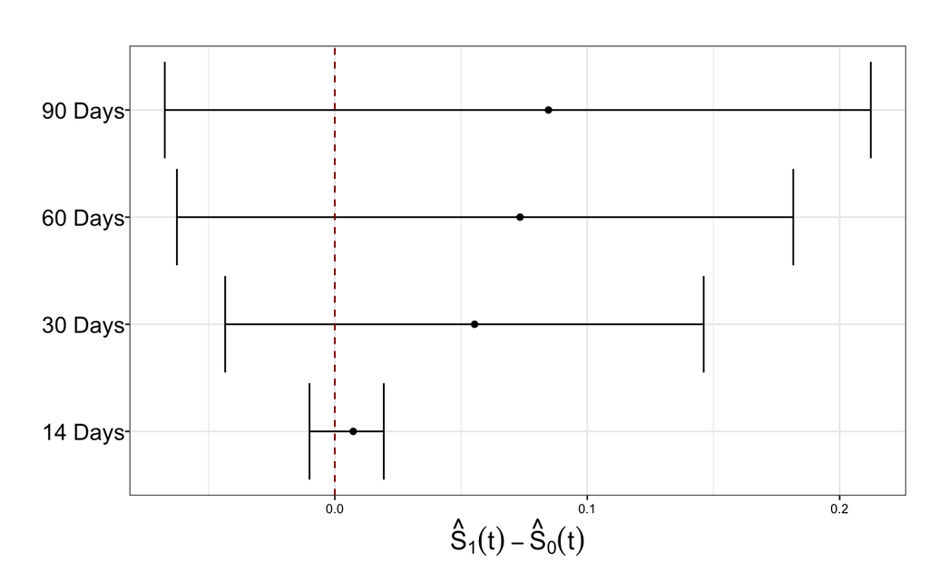

```r
est <- surv_est_dir6 %>%
  pivot_wider(names_from=treatment, values_from=mean_surv) %>%
  mutate(difference=`Prophylactic Use of Methotrexate`-`No Prophylactic Use of Methotrexate`) %>%
  filter(time == 10 | time == 30 | time == 53 |
           time== 88) %>%
  pull(difference)


boot_surv <- readRDS(here('data/boot_surv_directive_6.RDS'))

boot_surv %>%
  group_by(time) %>%
  summarize(lower = quantile(difference,.05),
            upper=quantile(difference,.95)) %>%
  bind_cols(estimate=est) %>%
  mutate(
         time_lab = paste0(time, " Days"),
         time_lab=factor(time_lab),
         time_lab=fct_reorder(time_lab,time)) %>%
  ggplot(aes(y=time_lab, xmin=lower,xmax=upper)) +
  geom_point(aes(y=time_lab,x=estimate))+
  geom_errorbar() +
  theme_c(axis.title.x=element_text(size=16),
          axis.text.y=element_text(size=14)) +
  geom_vline(aes(xintercept=0), color="darkred", linetype=2) +
  labs(x = latex2exp::TeX("$\\hat{S}_1(t) - \\hat{S}_0(t)$"),
       y="")
```

```r
library(kableExtra)

boot_surv %>%
  group_by(time) %>%
  summarize(lower = quantile(difference,.05),
            upper=quantile(difference,.95)) %>%
  mutate(across(where(is.numeric), ~round(.x,4))) %>%
  kbl(caption="Bootstrap Confidence Intervals for $\\hat{S}_1(t) - \\hat{S}_0(t)$") %>%
  kable_paper()
```

Bootstrap Confidence Intervals for $\hat{S}_1(t) - \hat{S}_0(t)$

| time | lower | upper |
| --- | --- | --- |
| 14 | -0.0100 | 0.0194 |
| 30 | -0.0435 | 0.1461 |
| 60 | -0.0626 | 0.1816 |
| 90 | -0.0674 | 0.2124 |

# Directive 7

> Based on the available data, is recovery of normal platelet levels associated with improved disease-free survival? Is it associated with a decreased risk of relapse?

While death could act as a competing event, no patient in our sample died before their return to normal platelet levels, so it was not necessary to handle competing events for this analysis.

To evaluate whether there is association between the recovery of normal platelet levels and the risk of relapse, we do need to handle the fact that death is a competing event. To do so, we use a semiparametric proportional sub-distribution odds model

## Is recovery of normal platelet levels associated with improved disease-free survival?

```r
# Age, fab classification, wait time until transplant, donor age, donor sex, cmv, sex, donor cmv, disease group

dat <- bmt %>%
  select(age,fab, waittime, disgroup,
         deltap, tp, deltadfs, sex_mismatch,
         cmv_mismatch,donorage,mtx,
         tdfs) %>%
  mutate(id=row_number())

dat <- tmerge(dat, dat, id=id,endpt=event(tdfs,deltadfs))
dat <- tmerge(dat, dat, id=id, plat=tdc(tp, deltap,init=0))

model <- coxph( Surv(tstart, tstop, endpt) ~ age +
                  #waittime + fab +
         cmv_mismatch  + disgroup + plat +donorage + sex_mismatch +
           mtx, data=dat)

gtsummary::tbl_regression(model,
                          label=list(plat="Platelet Count",
                                     age="Age",
                                     fab="FAB Classification",
                                     male="Sex",
                                     disgroup="Disease Group",
                                     cmv="Patient CMV"#,
                                     # waittime="Wait Time"
                                     ),
                          exponentiate=TRUE,
                          conf.level=.9)
```

| **Characteristic** | **HR**<sup>1</sup> | **90% CI**<sup>1</sup> | **p-value** |
| --- | --- | --- | --- |
| Age | 1.00 | 0.97, 1.04 | 0.8 |
| cmv_mismatch |  |  |  |
| CMV Negative->CMV Negative | — | — |  |
| CMV Negative->CMV Positive | 1.10 | 0.65, 1.86 | 0.8 |
| CMV Positive->CMV Negative | 1.00 | 0.55, 1.83 | >0.9 |
| CMV Positive->CMV Positive | 0.84 | 0.51, 1.37 | 0.6 |
| Disease Group |  |  |  |
| Acute Lymphoblastic Leukemia | — | — |  |
| Acute Myelocytic Leukemia (Low Risk) | 0.60 | 0.35, 1.02 | 0.11 |
| Acute Myelocytic Leukemia (High Risk) | 1.38 | 0.84, 2.28 | 0.3 |
| Platelet Count | 0.32 | 0.18, 0.56 | <0.001 |
| donorage | 1.01 | 0.98, 1.04 | 0.6 |
| sex_mismatch |  |  |  |
| Match | — | — |  |
| Male->Female | 1.38 | 0.88, 2.15 | 0.2 |
| Female->Male | 1.12 | 0.67, 1.87 | 0.7 |
| mtx |  |  |  |
| No Prophylactic Use of Methotrexate | — | — |  |
| Prophylactic Use of Methotrexate | 1.19 | 0.76, 1.86 | 0.5 |

<sup>1</sup> HR = Hazard Ratio, CI = Confidence Interval

```r
#-----------------------
# marginal model
#-----------------------

model <- coxph( Surv(tstart, tstop, endpt) ~plat, data=dat)

gtsummary::tbl_regression(model,
                            label=list(plat="Platelet Count",
                                       age="Age",
                                       fab="FAB Classification",
                                       male="Sex",
                                       disgroup="Disease Group",
                                       cmv="Patient CMV"#,
                                       # waittime="Wait Time"
                                       ),
                            exponentiate=TRUE,
                            conf.level=.9)
```

| **Characteristic** | **HR**<sup>1</sup> | **90% CI**<sup>1</sup> | **p-value** |
| --- | --- | --- | --- |
| Platelet Count | 0.28 | 0.16, 0.48 | <0.001 |

<sup>1</sup> HR = Hazard Ratio, CI = Confidence Interval

## Is recovery of normal platelet levels associated with relapse?

```r
dat <- bmt %>%
  select(age,fab, waittime, disgroup,
         deltap, tp, deltadfs, deltar, deltas, sex_mismatch,cmv_mismatch,donorage,
         tdfs) %>%
  mutate(id=row_number())

dat <- tmerge(dat, dat, id=id,endpt=event(tdfs,deltadfs))
dat <- tmerge(dat, dat, id=id, plat=tdc(tp, deltap,init=0))



library(timereg)

dat <- dat %>%
  mutate(cause = case_when(
    deltas == 1 & deltar == 0 ~ 1,
    deltar == 1 ~ 2,
    deltar == 0 & deltas == 0 ~ 0
  ),
  cause=as.integer(cause))

bmt_copy <- bmt



odds_mod <- prop.odds.subdist(Event(tdfs, cause) ~ plat,
         cause = 2,
         data=dat)

odds_mod <- prop.odds.subdist(Event(tdfs, cause) ~
                           age + fab +# waittime +
         cmv_mismatch  + disgroup  +donorage + sex_mismatch +
           plat,
         cause = 2,
         data=dat)

coef(odds_mod) %>% as.data.frame() %>%
  as_tibble(rownames="variable") %>%
  mutate(across(where(is.numeric), ~round(.x,4))) %>%
  kbl() %>%
  kable_paper()
```

| variable | Coef. | SE | Robust SE | D2log(L)^-1 | z | P-val | lower2.5% | upper97.5% |
| --- | --- | --- | --- | --- | --- | --- | --- | --- |
| age | 0.0407 | 0.0227 | 0.0263 | 0.0257 | 1.550 | 0.122 | -0.0038 | 0.0852 |
| fabFAB grade 4 or 5 and AML | 1.6500 | 0.3870 | 0.3850 | 0.3750 | 4.300 | 0.000 | 0.8910 | 2.4100 |
| cmv_mismatchCMV Negative->CMV Positive | 0.3690 | 0.4170 | 0.4290 | 0.3920 | 0.860 | 0.390 | -0.4480 | 1.1900 |
| cmv_mismatchCMV Positive->CMV Negative | -0.0995 | 0.4750 | 0.4940 | 0.4860 | -0.202 | 0.840 | -1.0300 | 0.8310 |
| cmv_mismatchCMV Positive->CMV Positive | 0.3240 | 0.3720 | 0.3880 | 0.3790 | 0.837 | 0.403 | -0.4050 | 1.0500 |
| disgroupAcute Myelocytic Leukemia (Low Risk) | -2.1700 | 0.5200 | 0.5160 | 0.4780 | -4.210 | 0.000 | -3.1900 | -1.1500 |
| disgroupAcute Myelocytic Leukemia (High Risk) | -0.6570 | 0.4740 | 0.4640 | 0.4430 | -1.420 | 0.157 | -1.5900 | 0.2720 |
| donorage | -0.0382 | 0.0236 | 0.0261 | 0.0234 | -1.460 | 0.143 | -0.0845 | 0.0081 |
| sex_mismatchMale->Female | 0.1980 | 0.3320 | 0.3430 | 0.3320 | 0.577 | 0.564 | -0.4530 | 0.8490 |
| sex_mismatchFemale->Male | -0.7090 | 0.4290 | 0.4420 | 0.4110 | -1.610 | 0.108 | -1.5500 | 0.1320 |
| plat | 0.0535 | 0.2800 | 0.2810 | 0.2780 | 0.190 | 0.849 | -0.4950 | 0.6020 |

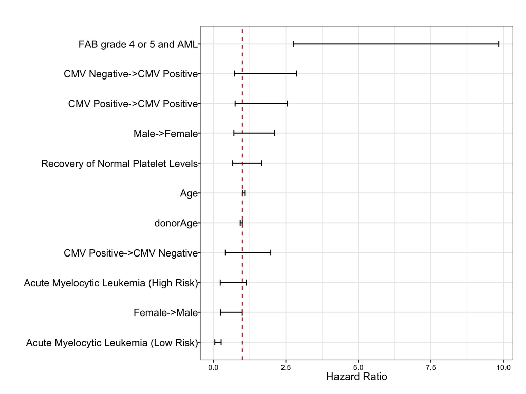

```r
coef(odds_mod) %>% as.data.frame() %>%
  as_tibble(rownames="variable") %>%
  rename(coef=`Coef.`) %>%
  mutate(lower = coef + qnorm(.05)*SE,
         upper= coef+ qnorm(.95)*SE) %>%
  mutate(across(c(coef,lower,upper),exp)) %>%
  mutate(variable=gsub(
    "sex_mismatch|disgroup|cmv_mismatch|fab|mtx",
    "",variable),
    variable=gsub("plat", "Recovery of Normal Platelet Levels", variable),
    variable=gsub("waittime", "Wait Time for Transplant", variable),
    variable=gsub("age", "Age", variable)) %>%
#  mutate(across(c(`Coef.`, `lower2.5%`,`upper97.5%`), exp)) %>%
  ggplot(aes(y=fct_reorder(variable,coef),
             xmin=lower,
             xmax=upper)) +
  geom_errorbar(width=.2) +
  geom_vline(xintercept=1,linetype=2,color="darkred") +
  theme_c(axis.text.y=element_text(size=11, hjust=1),
          axis.title.x=element_text(size=11.5)) +
  labs(y="", x="Hazard Ratio")
```

```r
ggsave(here("figures/directive_7.jpeg"))
```

```r
dat <- bmt %>%
  select(age,fab, waittime, cmv_mismatch, sex_mismatch, male, disgroup,
         deltap, tp, deltadfs, donorage,donormale,
         tdfs) %>%
  mutate(id=row_number())

dat <- tmerge(dat, dat, id=id,endpt=event(tdfs,deltadfs))
dat <- tmerge(dat, dat, id=id, plat=tdc(tp, deltap,init=0))

model <- coxph( Surv(tstart, tstop, endpt) ~ age + fab + waittime +
         cmv + male + disgroup + plat +donorage+donormale, data=dat)

gtsummary::tbl_regression(model,
                          label=list(plat="Platelet Count",
                                     age="Age",
                                     fab="FAB Classification",
                                     male="Sex",
                                     disgroup="Disease Group",
                                     cmv="Patient CMV",
                                     waittime="Wait Time"),
                          exponentiate=TRUE,
                          conf.level=.9)
```

```r
get_marginal_surv <- function(dat) {

  model <- coxph(Surv(ta, deltaa) ~
                 mtx + age + donorage +
                 waittime +
                 fab + disgroup+
                 sex_mismatch  +
                 cmv_mismatch, data=dat
               )

  surv_treat <- survfit(model, newdata=dat %>%
            mutate(mtx="Prophylactic Use of Methotrexate")) %>%
    broom::tidy() %>%
    rowwise() %>%
    mutate(
      mean_surv = mean(c_across(contains("estimate")), na.rm = TRUE)
    ) %>%
    ungroup() %>%
    select(time, surv_treat = mean_surv)

  surv_no_treat <- survfit(model, newdata=dat %>%
          mutate(mtx="No Prophylactic Use of Methotrexate")) %>%
    broom::tidy() %>%
    rowwise() %>%
    mutate(
      mean_surv = mean(c_across(contains("estimate")), na.rm = TRUE)
    ) %>%
    ungroup() %>%
    select(time, surv_no_treat= mean_surv)

  surv_treat %>%
    left_join(surv_no_treat)

}

boot_surv <- map_df(1:100, ~ {
  ind <- sample(1:nrow(bmt), replace=TRUE)
  boot_samp <- bmt[ind,]
  get_marginal_surv(boot_samp)
})

saveRDS(boot_surv, here('data/boot_surv_directive_6.RDS'))

boot_summary <- boot_surv |>
  group_by(time) |>
  summarise(
    S1_lo = quantile(surv_treat, 0.025, na.rm = TRUE),
    S1_hi = quantile(surv_treat, 0.975, na.rm = TRUE),
    S0_lo = quantile(surv_no_treat, 0.025, na.rm = TRUE),
    S0_hi = quantile(surv_no_treat, 0.975, na.rm = TRUE),
    .groups = "drop"
  ) %>%
  pivot_longer(-c(time)) %>%
  mutate(treatment = ifelse(grepl("S1", name),
                             "Prophylactic Use of Methotrexate",
                            "No Prophylactic Use of Methotrexate"),
         new_name = ifelse(grepl("lo", name), "lower","upper")) %>%
  select(-name) %>%
  pivot_wider(values_from=value,names_from=new_name)


boot_surv %>%
  mutate(difference=surv_treat-surv_no_treat) %>%
  group_by(time) %>%
  summarize(lower=quantile(difference,.025),
            upper=quantile(difference,.975)) %>%
  ggplot(aes(x=time, ymin =lower, ymax=upper)) +
  geom_errorbar()

surv_est_dir6 %>%
  left_join(boot_summary) %>%
  mutate(maxtime=lead(time,n=1)) %>%
  ggplot(aes(x=time, y=mean_surv, color=treatment))+
  geom_step() +
  coord_cartesian(xlim=c(0,150)) +
  theme_c()

+
  viridis::scale_color_viridis(
      discrete=TRUE, option="mako", end=.8, begin=.2) +
  labs(x="Time (Days)", y = "Event-Free Survival") +
  geom_rect(aes(xmin = time, xmax = maxtime,
                ymin = lower, ymax = upper,
                fill=treatment),
              alpha = 0.15,
              inherit.aes=FALSE)
```

```r
model <- coxph(Surv(ta, deltaa) ~mtx + age + donorage +
                 waittime + fab +
                 donormale + male +
                 cmv + donorcmv +
                 disgroup, data=bmt
               )



tbl_regression(model)
```